# Walkability Analysis

Nicholas Geron

2025-02-16

# Walkability Analysis

## Background Information

For the final project, our research will focus on identifying the presence of food deserts within the study area of Danvers, Beverly, Peabody, Lynn, and Salem, Massachusetts, and examining their relationship to income levels and other socioeconomic variables. A food desert is defined as an area with limited access to affordable and nutritious food, often due to factors like distance to the nearest grocery store, lack of public transportation, and income disparities. By mapping the spatial distribution of food distribution sites, particularly food pantries, and correlating these locations with income data, we aim to determine if low-income neighborhoods are disproportionately affected by limited access to healthy food options. This research is crucial in understanding the broader implications of food insecurity in the context of natural disasters, such as floods, and how certain areas may face heightened challenges in accessing essential resources during such events. Using available GIS tools, such as the EPA Walkability Index, I will assess how walkability impacts access to food distribution sites in these low-income regions. The findings will contribute to ongoing discussions about food equity, specifically by highlighting areas where interventions may be necessary to improve access to nutritious food for underserved populations. This research will inform future policy decisions and emergency planning efforts related to food accessibility.

## Data Layers

#### Walk Potential/Bike Potential:

From MassDOT, the walking and biking potential layers use multiple different equations to create a tile layer covering the entire state that classifies areas as high, medium, and low potential. Created in 2022 these layers are the most updated version that massDOT has released to the public, created using four different factors (social equity, potential demand, crashes, and transit access). This did not require collection - but rather compiling. This data will provide already calculated potential information to the data model.The equation that MassDOT used is : Potential for everyday walking = (0.7 * Potential Demand + 0.2 * Transportation Access) + (1 + Social Equity)) The demand coming from Potential walking demand (Local Access Score) and Streetlight data (of all trips under 3 miles). Transportation Acces indicaates all areas within a 10 minute walk from any transit hub. Finally, Social equity takes into account: Minorities, no-vehicle households, low-income households, Limited English speaking households, people with disabilities, under 18 and over 65 along with streetlight obtained demographic data.

#### Food Distribution Centers

THERE ARE ISSUES WITH THE FOOD DISTRIBUTION STORE TYPES - need to edit the original layers.

The Food Distribution was collected by the Greenbelt Organization, a local non-profit dedicated to preserving open space and promoting community well-being. This data was gathered through field surveys, community outreach, and collaborations with local food distribution sites to assess both food availability and the walkability of surrounding areas. The data includes the locations of food pantries and other distribution sites, as well as walkability scores for each area, which were calculated based on factors like sidewalk presence, street connectivity, and pedestrian infrastructure. The food distribution data is categorical, identifying whether a site is a food pantry, while the walkability data is continuous, representing varying levels of pedestrian access across the region. This dataset will play a crucial role in identifying potential food deserts within the study area and evaluating how accessible these resources are for the population, particularly in relation to income levels, flood risk, and transportation access. By mapping these data points, this research can identify areas where food access is limited, especially for individuals without reliable transportation, contributing to the broader goal of understanding food equity and accessibility during emergencies

## Analysis

```r
# Install the required packages if not already installed
#install.packages(c("argparse", "elevatr", "glue", "sf", "terra", "tidycensus", "tigris", "units", "yaml"))

# Install and load required packages if not already done
# Load libraries
# Load required libraries
library(tidycensus)
library(tigris)
library(dplyr)
library(sf)
library(ggplot2)
library(ggspatial)
library(tmap)
library(tidyverse)
library(viridis)
library(elevatr)
library(glue)
library(terra)
library(units)
library(yaml)
library(randomForest)
library(caret)
library(multcomp)
```

Import data

```r
##################################################################################
###    Town Boundaries

# Define the working CRS (Massachusetts State Plane projection)
working_crs <- 26986  # EPSG code for Massachusetts State Plane

# Step 1: Load the town boundary shapefile (CENSUS2020TOWNS_POLY_CopyFeatures.shp)
town_boundary_path <- "./Data/CENSUS2020TOWNS_SHP/CENSUS2020TOWNS_POLY.shp"
town_boundaries <- st_read(town_boundary_path) %>%
  st_transform(crs = working_crs)
```

```r
town_boundaries$TOWN20 <- as.character(town_boundaries$TOWN20)

fivetowns <- town_boundaries %>% filter(TOWN20 %in% c("BEVERLY", "SALEM", "LYNN", "DANVERS", "PEABODY"))

##################################################################################
###    Census Data

# Set your Census API key
#census_api_key("405a3863533a4f16492fae1fe5de97d938b75fe8", overwrite = TRUE)

# Updated get_acs call with all codes
#MA_ACS_blkgrp <- get_acs(
#  geography = "block group",
#  variables = c(
#    totalpop = "B03002_001",
#    whitepop = "B03002_003",
#    blackpop = "B03002_004",
#    hispanicpop = "B03002_012",
#    engLangIso = "C16002_004",
#    totalHouseholds = "B11001_001",
#    medHouseholdInc = "B19013_001",
#    edTotal = "B15003_001",
#    edBA = "B15003_022",
#    edMA = "B15003_023",
#    edProf = "B15003_024",
#    edDr = "B15003_025",
#    totalInLaborForce = "B23025_003",
#    unempInLaborForce = "B23025_005",
#    totalpop18 = "B01001_001",
#    veteranStatus = "B21001_001",      # Veteran status example
#    healthInsurance = "B08302_008",
#    totalworkers = "B08301_001",
#    walk_to_work = "B08301_019",       # Workers walking to work
#    publictransit = "B08301_010",
#    public_transit = "B08301_016",     # Workers using public transit
#    no_vehicle = "B25044_003",         # Households with no vehicle
#    one_vehicle = "B25044_010"         # Households with one vehicle# Households with health #insurance
#  ),
#  state = "MA",
#  output = "wide"
#)

#names(MA_ACS_blkgrp)

# Create percentage variables
#MA_ACS_blkgrp1 <- MA_ACS_blkgrp %>%
#  mutate(
#    PctWhite = whitepopE / totalpopE,
#    PctBlack = blackpopE / totalpopE,
#    PctHispanic = hispanicpopE / totalpopE,
#    PctLimEngl = engLangIsoE / totalHouseholdsE,
#    peroneorless = (no_vehicleE + one_vehicleE)/ totalHouseholdsE,
#    perwalkers = walk_to_workE / totalworkersE,
#    perpublictrans = publictransitE/ totalworkersE,
#    perveterans = veteranStatusE / totalpop18E,
#    per_unemployed = unempInLaborForceE / totalInLaborForceE,
#    per_bachormore = (edBAE + edMAE + edProfE + edDrE) / edTotalE,
#  ) %>%
#  select(GEOID, PctWhite, PctBlack, PctHispanic, PctLimEngl, medHouseholdIncE, totalpopE, #per_bachormore, peroneorless, perwalkers, perpublictrans, perveterans, per_unemployed)

# Load block group shapefile for Massachusetts using tigris
#MA_blockgrp <- block_groups(state = "MA", year = 2020, class = "sf")

# Ensure GEOID is the same type in both datasets
#MA_blockgrp$GEOID <- as.character(MA_blockgrp$GEOID)

# Perform a non-spatial join (using GEOID) to add the ACS data to the block group shapefile
#MA_blockgrp_data <- left_join(MA_blockgrp, MA_ACS_blkgrp1, by = "GEOID")

#MA_blockgrp_data <- st_transform(MA_blockgrp_data, crs = working_crs)

#MA_blockgrp_geo_five_towns <- st_intersection(MA_blockgrp_data, fivetowns)

##################################################################################
###    Food Distribution Sites

# Load food sites shapefile
file_path_food_sites <- "./Data/NSFFC_Food_Access/FarmStands_FarmersMarkets_Merge.shp"
farmstands <- st_read(file_path_food_sites) %>%
  st_transform(crs = working_crs)
```

```
## replacing null geometries with empty geometries
## Simple feature collection with 32 features and 28 fields (with 1 geometry empty)
## Geometry type: POINT
## Dimension:     XY
## Bounding box:  xmin: -71.0072 ymin: 42.45929 xmax: -70.84974 ymax: 42.60814
## Geodetic CRS:  WGS 84
```

```r
# Step 4: Load food sites shapefile (FoodSites_FarmersMarkets_Merge.shp)
grocerystores_path <- "./Data/NSFFC_Food_Access/grocerystores_merge.shp"
grocerystores <- st_read(grocerystores_path) %>%
  st_transform(crs = working_crs)  # Transform food sites to the correct CRS
names(grocerystores)
```

```
##  [1] "Store_Name" "Store_Type" "Full_Addre" "City"       "Source"
##  [6] "F_id"       "website"    "addr_house" "addr_postc" "addr_state"
## [11] "addr_stree" "opening_ho" "phone"      "Store_Stre" "Additonal_"
## [16] "State"      "Zip_Code"   "Zip4"       "County"     "Latitude"
## [21] "Longitude"  "Incentive_" "Grantee_Na" "ObjectId_1" "MERGE_SRC"
## [26] "geometry"
```

```r
view(grocerystores)

# Step 4: Load food sites shapefile (FoodSites_FarmersMarkets_Merge.shp)
foodoutside_path <- "./Data/NSFFC_Food_Access/Foodoutside5towns.shp"
foodoutside <- st_read(foodoutside_path) %>%
  st_transform(crs = working_crs)  # Transform food sites to the correct CRS
names(foodoutside)
```

```
## [1] "Store_Name" "Store_Type" "Full_Addre" "Notes"      "City"
## [6] "Source"     "geometry"
```

```r
# Step 4: Load food sites shapefile (FoodSites_FarmersMarkets_Merge.shp)
foodbanks_path <- "./Data/NSFFC_Food_Access/FoodBanks.shp"
foodbanks <- st_read(foodbanks_path) %>%
  st_transform(crs = working_crs)  # Transform food sites to the correct CRS
names(foodbanks)
```

```
##  [1] "City"       "addr_house" "addr_postc" "addr_state" "addr_stree"
##  [6] "amenity"    "Store_Name" "opening_ho" "social_fac" "social_f_1"
## [11] "Store_Type" "Full_Addre" "Source"     "geometry"
```

```r
#Select variables for merging foodfiles
foodbanks4 <- foodbanks %>%
  dplyr::select(City, Store_Type, Store_Name, geometry)

#Select variables for merging foodfiles
grocerystores4 <- grocerystores %>%
  dplyr::select(City, Store_Type, Store_Name, geometry)

#Select variables for merging foodfiles
foodoutside4 <- foodoutside %>%
  dplyr::select(City, Store_Type, Store_Name, geometry)

#Select variables for merging foodfiles
farmstands4 <- farmstands %>%
  dplyr::select(City, Store_Type, Store_Name, geometry)

ALLfoodsites <- rbind(farmstands4, grocerystores4, foodbanks4)

ALLfoodsites$uniqueID <- 1:nrow(ALLfoodsites) + 100

# Condense classifications into specified categories
ALLfoodsites1 <- ALLfoodsites %>%
  mutate(Store_Type = case_when(
    Store_Type %in% c("Butcher") ~ "Butcher",
    Store_Type %in% c("Convenience", "Gas Station") ~ "Convenience",
    Store_Type %in% c("Farm Stand") ~ "Farm",
    Store_Type %in% c("Farmers Markets", "Winter Markets") ~ "Farmer Markets",
    Store_Type %in% c("Food Pantry") ~ "Food Pantry",
    Store_Type %in% c("Grocery Store", "Super Store", "Supermarket") ~ "Stores/Supermarkets",
    TRUE ~ "Other"  # Retain "Other" as a category
  ))

# Optionally, check the count of each category to confirm
foodsite_summary <- ALLfoodsites1 %>%
  group_by(Store_Type) %>%
  summarise(Count = n())

# Create an 800m buffer around each food distribution site
food1_buffers <- st_buffer(ALLfoodsites1, dist = 800)


##################################################################################
###    Walkability Data

# Step 4: Load Road Inventory Shapefile
#walking_potential <- st_read("./Data/MA_walkabilityindex/Potential_for_Walkable_Trips_2022_Update#.shp") %>%
#  st_transform(crs = working_crs)

#filtered_walkability <- walking_potential %>%
#  dplyr::select(walking_po, geometry)

# View the first few rows of the filtered data
#head(filtered_walkability)

#st_crs(fivetowns) == st_crs(filtered_walkability)

#drop m
#filtered_walkability_zm <- st_zm(filtered_walkability)

#filtered_walkability_zm$walking10 <- filtered_walkability_zm$walking_po * 10000

#filtered_walkability_zm5towns <- st_intersection(filtered_walkability_zm, fivetowns)

#st_write(filtered_walkability_zm5towns, "./Data/MA_walkabilityindex/fivetowns_walkability1.shp")

# Step 5: Spatial Join of Road Data with Census Block Groups
#MA_blockgrp_geo_five_towns1 <- st_join(MA_blockgrp_geo_five_towns, filtered_walkability_zm, join = #st_intersects)

# Summarize walking_po to calculate average value by GEOID, scaled by 1000
#summary_data <- MA_blockgrp_geo_five_towns1 %>%
#  st_drop_geometry() %>%  # Remove spatial geometry for summarization
#  mutate(walking_po_scaled = walking_po * 10000) %>%  # Scale walking_po values by 10000
#  group_by(GEOID) %>%     # Group by GEOID (or another unique identifier)
#  summarise(
#    average_walking_potential = mean(walking_po_scaled, na.rm = TRUE),  # Calculate average scaled #walking potential
#    count = n()  # Count the number of rows per group
#  )


# Join summary_data back to spatial data for mapping
#MA_blockgrp_5_walkability <- left_join(MA_blockgrp_geo_five_towns, summary_data, by = "GEOID")

#Create smaller shapefile
#st_write(MA_blockgrp_5_walkability, #"./Data/Census_walkability5towns/maCensusblkgrp_walkability.shp")

# Load walkability Census Shapefile
MA_blockgrp_5_walk <- st_read("./Data/Census_walkability5towns/maCensusblkgrp_walkability.shp")
# Load walkability for 5 towns
fivetowns_walk <- st_read("./Data/MA_walkabilityindex/fivetowns_walkability1.shp")
###########################################################################################
###########    Commuter Rail Data

# Load Commuter Rail Station Data
commuterrailstations_path <- "./Data/CommuterRail/CommuterRailStations/MBTACommuterRailStations_projectarea.shp"
transit_points <- st_read(commuterrailstations_path) %>%
  st_transform(crs = working_crs)
# Load Commuter Rail Line Data
commuterrailline_path <- "./Data/CommuterRail/CommuterRailLines/MBTACommuterRailLines_projectarea.shp"
transit_lines <- st_read(commuterrailline_path) %>%
  st_transform(crs = working_crs)
#Clip Train line
transitlinesclipped <- st_intersection(transit_lines,fivetowns)
```

Create maps

```r
names(MA_blockgrp_5_walk)
```

```
##  [1] "STATEFP"   "COUNTYFP"  "TRACTCE"   "BLKGRPC"   "GEOID"     "NAMELSAD"
##  [7] "MTFCC"     "FUNCSTAT"  "ALAND"     "AWATER"    "INTPTLAT"  "INTPTLON"
## [13] "PctWhit"   "PctBlck"   "PctHspn"   "PctLmEn"   "mdHshIE"   "totlppE"
## [19] "pr_bchr"   "prnrlss"   "prwlkrs"   "prpblct"   "prvtrns"   "pr_nmpl"
## [25] "STATEFP2"  "COUNTYFP2" "COUSUBF"   "COUSUBN"   "GEOID20"   "NAMELSAD2"
## [31] "LSAD20"    "CLASSFP"   "MTFCC20"   "CNECTAF"   "NECTAFP"   "NCTADVF"
## [37] "FUNCSTAT2" "ALAND20"   "AWATER2"   "INTPTLAT2" "INTPTLON2" "TOWN20"
## [43] "TOWN_ID"   "FIPS_ST"   "COUNTY2"   "TYPE"      "FOURCOL"   "AREA_AC"
## [49] "SQ_MILE"   "POP1960"   "POP1970"   "POP1980"   "POP1990"   "POP2000"
## [55] "POP2010"   "POP2020"   "POPCH10"   "HOUSING"   "SHAPE_A"   "SHAPE_L"
## [61] "avrg_w_"   "count"     "geometry"
```

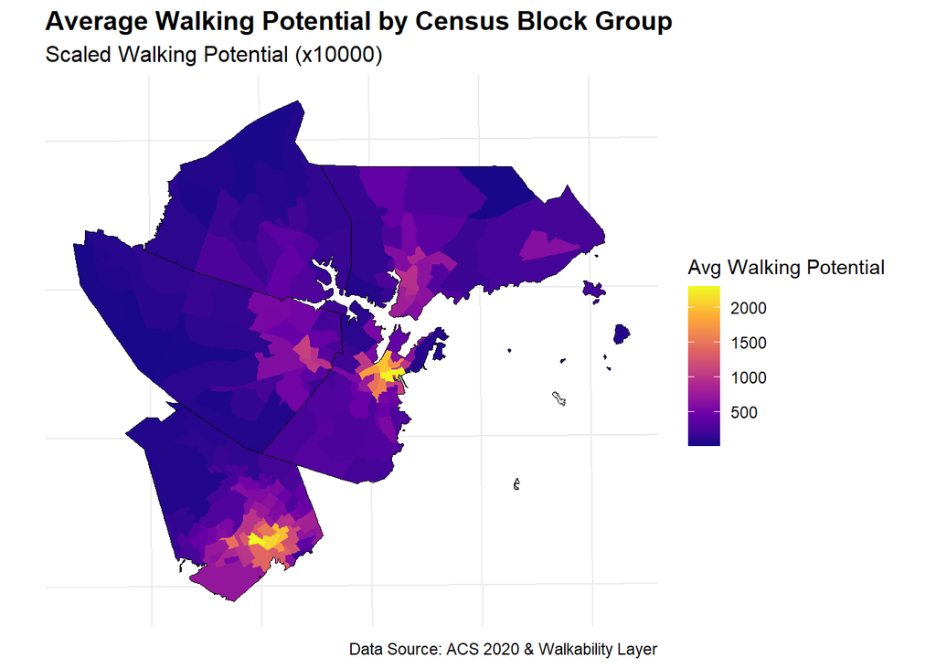

```r
# Create a map of the average walking potential
ggplot() +
  # Plot block groups with average walking potential
  geom_sf(data = MA_blockgrp_5_walk, aes(fill = avrg_w_), color = NA) +
  scale_fill_viridis_c(
    option = "plasma",
    name = "Avg Walking Potential",
    na.value = "grey90"
  ) +
  # Overlay town boundaries for context
  geom_sf(data = fivetowns, fill = NA, color = "black", size = 0.5) +
  theme_minimal() +
  labs(
    title = "Average Walking Potential by Census Block Group",
    subtitle = "Scaled Walking Potential (x10000)",
    caption = "Data Source: ACS 2020 & Walkability Layer"
  ) +
  theme(
    legend.position = "right",
    plot.title = element_text(size = 14, face = "bold"),
    plot.subtitle = element_text(size = 12),
    axis.text = element_blank(),
    axis.ticks = element_blank()
  ) +
  coord_sf()
```

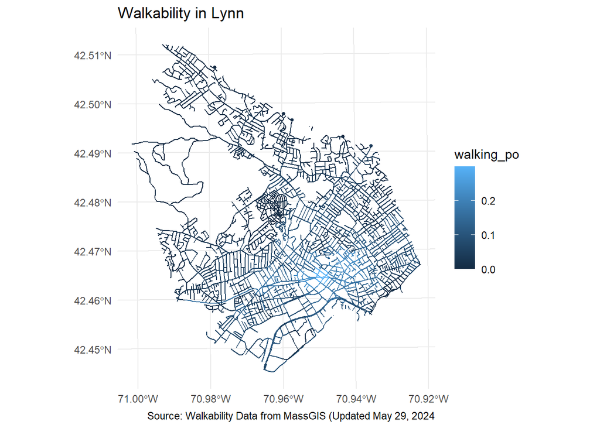

```r
#separate Lynn for case study
lynn <- fivetowns %>% filter(NAMELSAD20 %in% c("Lynn city"))

#Clip walkability to town_boundaries
walkabilitylynn <- st_intersection(fivetowns_walk, lynn)

#Choropleth map with ggplot
ggplot() +
  #Map fill by walking potential
  geom_sf(data = walkabilitylynn, aes(color = walking_po), size = 1) +
  scale_fill_viridis_c(
    option = "plasma",
    name = "Avg Walking Potential",
    na.value = "grey90")+
  theme_minimal() +
  labs(title = "Walkability in Lynn", caption = "Source: Walkability Data from MassGIS (Updated May 29, 2024") +
  theme(legend.position = "right")
```

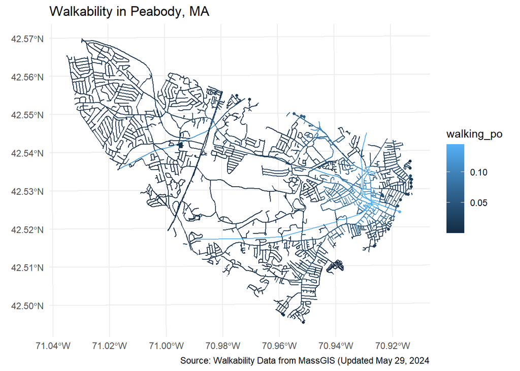

```r
#separate Peabody for case study
peabody <- fivetowns %>% filter(NAMELSAD20 %in% c("Peabody city"))

#Clip walkability to town_boundaries
walkabilitypeabody <- st_intersection(fivetowns_walk, peabody)

#Choropleth map with ggplot
ggplot() +
  #Map fill by walking potential
  geom_sf(data = walkabilitypeabody, aes(color = walking_po), size = 1) +
  scale_fill_viridis_c(
    option = "plasma",
    name = "Avg Walking Potential",
    na.value = "grey90")+
  theme_minimal() +
  labs(title = "Walkability in Peabody, MA", caption = "Source: Walkability Data from MassGIS (Updated May 29, 2024") +
  theme(legend.position = "right")
```

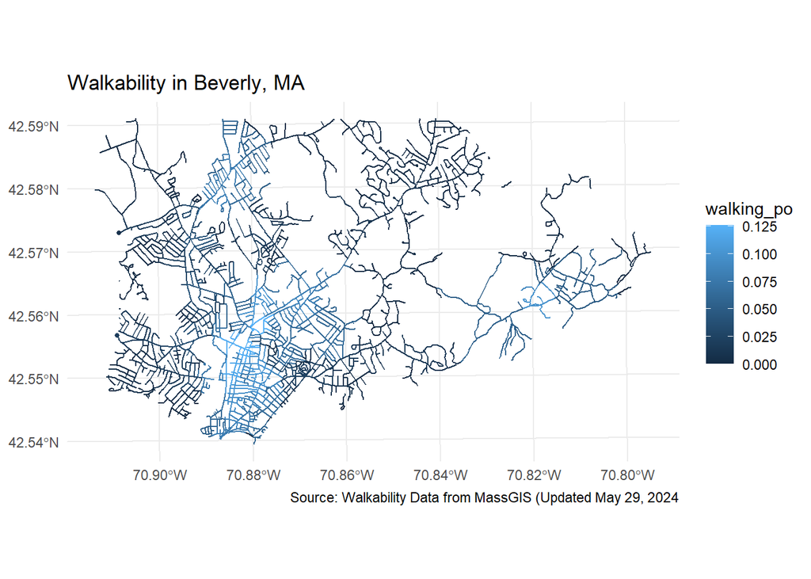

```r
#separate Beverly for case study
beverly <- fivetowns %>% filter(NAMELSAD20 %in% c("Beverly city"))

#Clip walkability to town_boundaries
walkabilitybeverly <- st_intersection(fivetowns_walk, beverly)

#Choropleth map with ggplot
ggplot() +
  #Map fill by walking potential
  geom_sf(data = walkabilitybeverly, aes(color = walking_po), size = 1) +
  scale_fill_viridis_c(
    option = "plasma",
    name = "Avg Walking Potential",
    na.value = "grey90")+
  theme_minimal() +
  labs(title = "Walkability in Beverly, MA", caption = "Source: Walkability Data from MassGIS (Updated May 29, 2024") +
  theme(legend.position = "right")
```

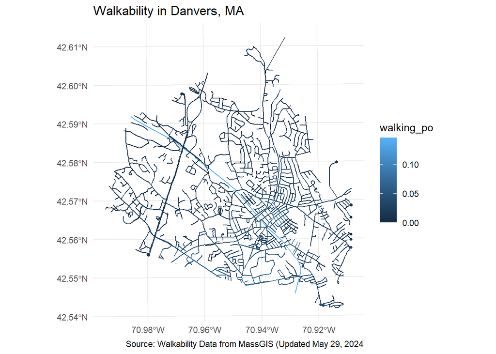

```r
#separate Danvers for case study
danvers <- fivetowns %>% filter(NAMELSAD20 %in% c("Danvers town"))

#Clip walkability to town_boundaries
walkabilitydanvers <- st_intersection(fivetowns_walk, danvers)

#Choropleth map with ggplot
ggplot() +
  #Map fill by walking potential
  geom_sf(data = walkabilitydanvers, aes(color = walking_po), size = 1) +
  scale_fill_viridis_c(
    option = "plasma",
    name = "Avg Walking Potential",
    na.value = "grey90")+
  theme_minimal() +
  labs(title = "Walkability in Danvers, MA", caption = "Source: Walkability Data from MassGIS (Updated May 29, 2024") +
  theme(legend.position = "right")
```

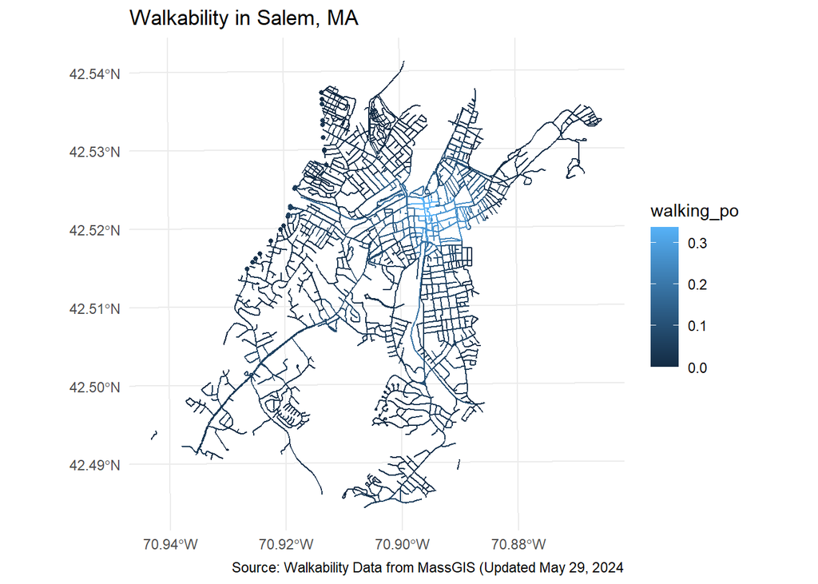

```r
#separate Salem for case study
salem <- fivetowns %>% filter(NAMELSAD20 %in% c("Salem city"))

#Clip walkability to town_boundaries
walkabilitysalem <- st_intersection(fivetowns_walk, salem)

#Choropleth map with ggplot
ggplot() +
  #Map fill by walking potential
  geom_sf(data = walkabilitysalem, aes(color = walking_po), size = 1) +
  scale_fill_viridis_c(
    option = "plasma",
    name = "Avg Walking Potential",
    na.value = "grey90")+
  theme_minimal() +
  labs(title = "Walkability in Salem, MA", caption = "Source: Walkability Data from MassGIS (Updated May 29, 2024") +
  theme(legend.position = "right")
```

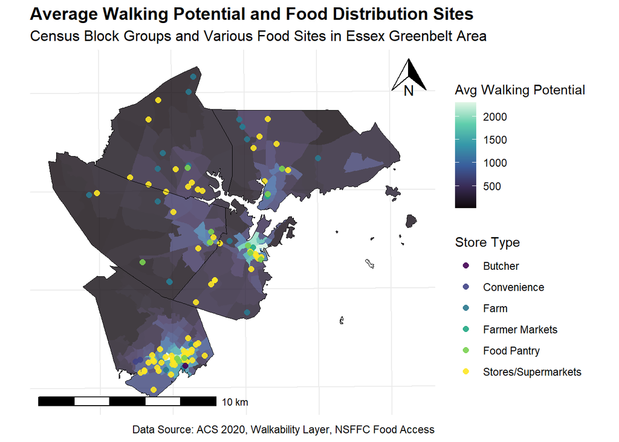

```r
# Combined map of Average Walking Potential and Food Distribution Sites
ggplot() +
  # Plot block groups with average walking potential
  geom_sf(data = MA_blockgrp_5_walk, aes(fill = avrg_w_), color = NA, alpha = 0.8) +
  scale_fill_viridis_c(
    option = "mako",
    name = "Avg Walking Potential",
    na.value = "grey90"
  ) +
  # Add the points for all food sites
  geom_sf(data = ALLfoodsites1, aes(color = Store_Type), size = 2, alpha = 0.9) +
  # Customize color scale for food site types
  scale_color_viridis_d(name = "Store Type") +
  # Overlay town boundaries for context
  geom_sf(data = fivetowns, fill = NA, color = "black", size = 0.5) +
  # Add labels and themes
  theme_minimal() +
  labs(
    title = "Average Walking Potential and Food Distribution Sites",
    subtitle = "Census Block Groups and Various Food Sites in Essex Greenbelt Area",
    caption = "Data Source: ACS 2020, Walkability Layer, NSFFC Food Access"
  ) +
  # Add north arrow and scale bar
  annotation_scale(location = "bl", width_hint = 0.5) +
  annotation_north_arrow(location = "tr", which_north = "true",
                         height = unit(1, "cm"), width = unit(1, "cm")) +
  # Adjust legend and text
  theme(
    legend.position = "right",
    plot.title = element_text(size = 14, face = "bold"),
    plot.subtitle = element_text(size = 12),
    axis.text = element_blank(),
    axis.ticks = element_blank()
  ) +
  coord_sf()
```

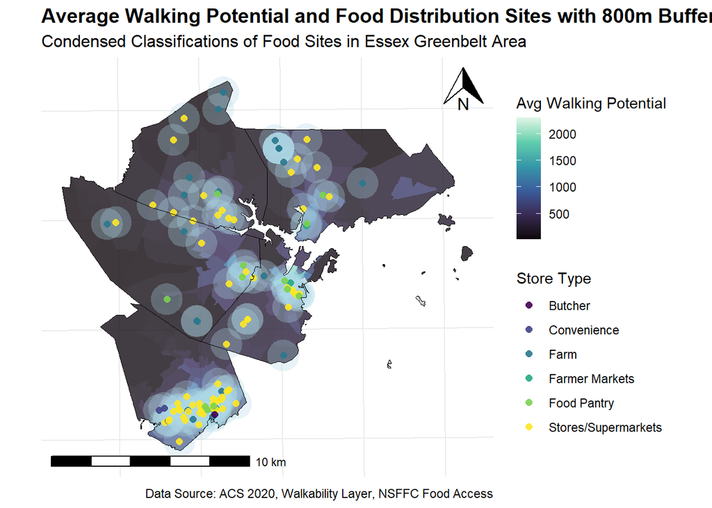

```r
# Map the condensed classifications with 800m buffers
ggplot() +
  # Plot block groups with average walking potential
  geom_sf(data = MA_blockgrp_5_walk, aes(fill = avrg_w_), color = NA, alpha = 0.8) +
  scale_fill_viridis_c(
    option = "mako",
    name = "Avg Walking Potential",
    na.value = "grey90"
  ) +
  # Add the 800m buffer zones
  geom_sf(data = food1_buffers, fill = "lightblue", color = NA, alpha = 0.3) +
  # Add the points for all food sites with updated classifications
  geom_sf(data = ALLfoodsites1, aes(color = Store_Type), size = 2, alpha = 0.9) +
  # Customize color scale for food site types
  scale_color_viridis_d(name = "Store Type") +
  # Overlay town boundaries for context
  geom_sf(data = fivetowns, fill = NA, color = "black", size = 0.5) +
  # Add labels and themes
  theme_minimal() +
  labs(
    title = "Average Walking Potential and Food Distribution Sites with 800m Buffers",
    subtitle = "Condensed Classifications of Food Sites in Essex Greenbelt Area",
    caption = "Data Source: ACS 2020, Walkability Layer, NSFFC Food Access"
  ) +
  # Add north arrow and scale bar
  annotation_scale(location = "bl", width_hint = 0.5) +
  annotation_north_arrow(location = "tr", which_north = "true",
                         height = unit(1, "cm"), width = unit(1, "cm")) +
  # Adjust legend and text
  theme(
    legend.position = "right",
    plot.title = element_text(size = 14, face = "bold"),
    plot.subtitle = element_text(size = 12),
    axis.text = element_blank(),
    axis.ticks = element_blank()
  ) +
  coord_sf()
```

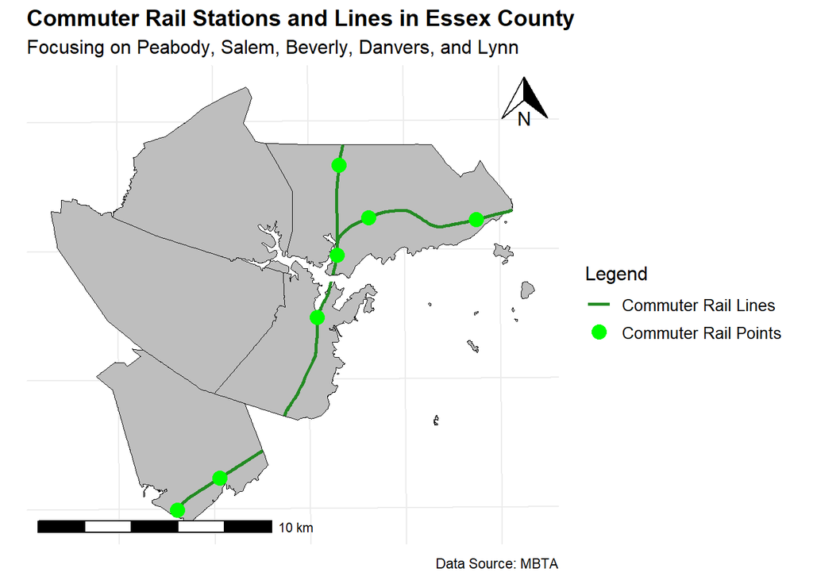

```r
#Commuter Rail Map
ggplot(data = fivetowns) +
  # Plot the town boundaries
  geom_sf(fill = "grey", color = "black", size = 0.5) +

  # Plot the transit lines with a mapped color for legend
  geom_sf(data = transitlinesclipped, aes(color = "Commuter Rail Lines"), fill = NA, linewidth = 1, linetype = "solid") +
  # Plot the transit points with a mapped color for legend
  geom_sf(data = transit_points, aes(color = "Commuter Rail Points"), size = 4, shape = 16) +

  #Change Feature Colors
  scale_color_manual(values = c("Commuter Rail Lines" = "forestgreen",
                                "Commuter Rail Points" = "green")) +
  # Add labels and themes
  theme_minimal() +
  labs(
    title = "Commuter Rail Stations and Lines in Essex County",
    subtitle = "Focusing on Peabody, Salem, Beverly, Danvers, and Lynn",
    caption = "Data Source: MBTA",
    color = "Legend"  # This will add a legend title
  ) +

  # Add north arrow and scale bar
  annotation_scale(location = "bl", width_hint = 0.5) +
  annotation_north_arrow(location = "tr", which_north = "true",
                         height = unit(1, "cm"), width = unit(1, "cm")) +

  # Adjust legend and text
  theme(
    legend.position = "right",
    plot.title = element_text(size = 14, face = "bold"),
    plot.subtitle = element_text(size = 12),
    axis.text = element_blank(),
    axis.ticks = element_blank(),
    legend.title = element_text(size = 12),
    legend.text = element_text(size = 10)
  ) +
  coord_sf()
```

Analyze Variables

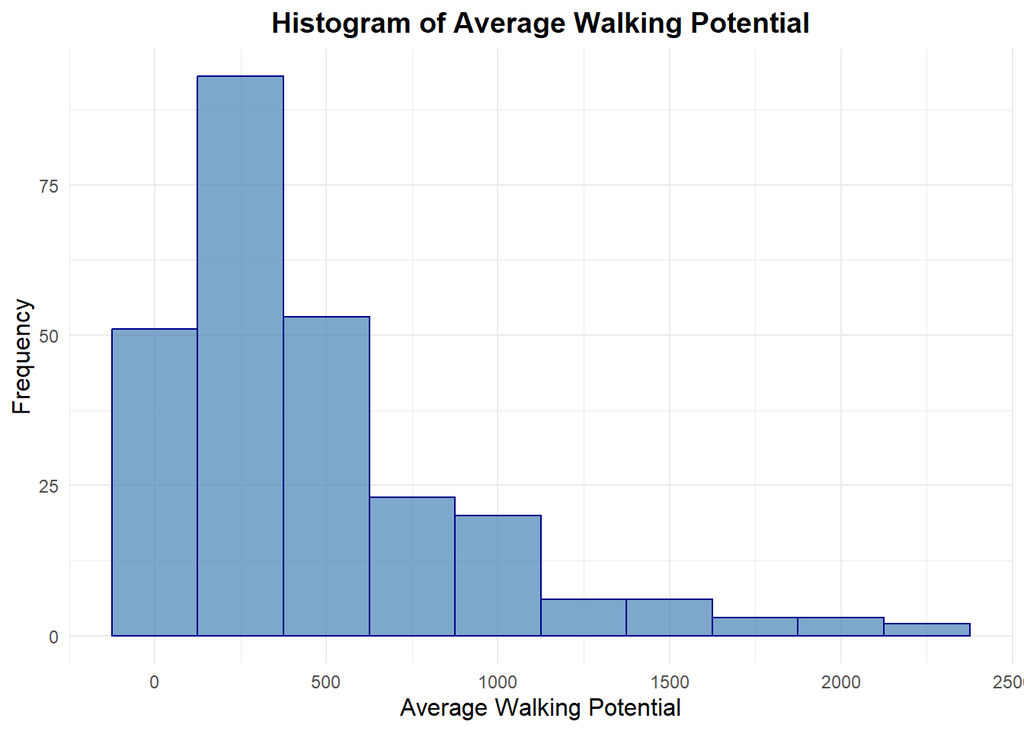

```r
# Create a histogram for average walking potential
ggplot(MA_blockgrp_5_walk, aes(x = avrg_w_)) +
  geom_histogram(binwidth = 250, fill = "steelblue", color = "darkblue", alpha = 0.7) +
  labs(
    title = "Histogram of Average Walking Potential",
    x = "Average Walking Potential",
    y = "Frequency"
  ) +
  theme_minimal() +
  theme(
    plot.title = element_text(size = 14, face = "bold", hjust = 0.5),
    axis.title.x = element_text(size = 12),
    axis.title.y = element_text(size = 12)
  )
```

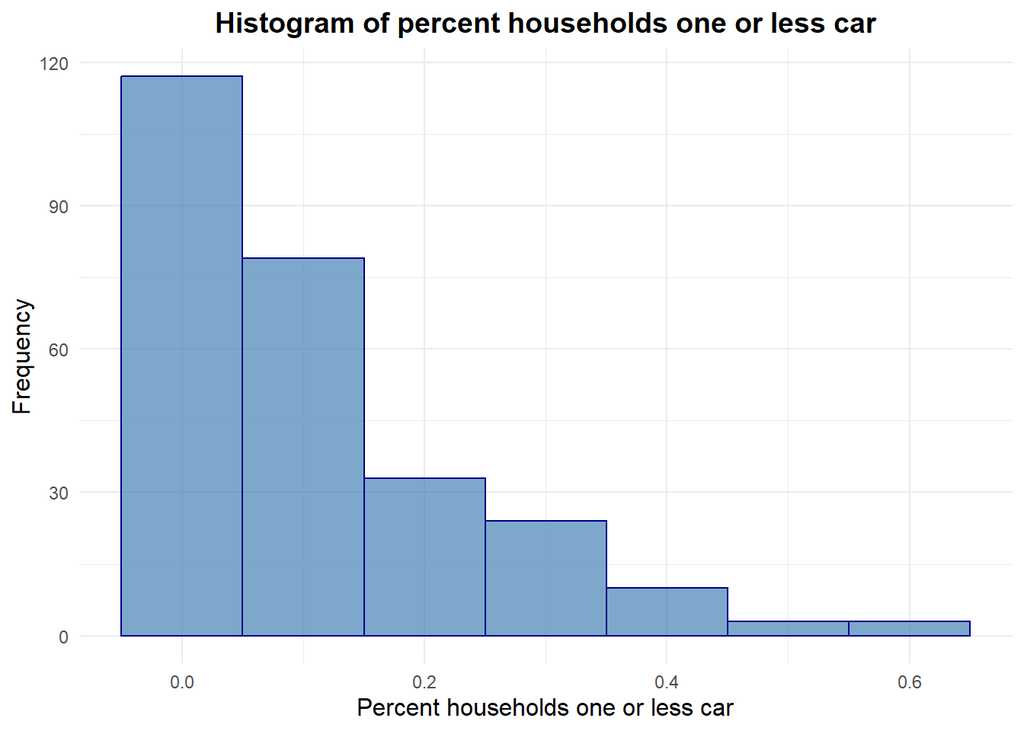

```r
# Create a histogram for percent households one or less car
ggplot(MA_blockgrp_5_walk, aes(x = prnrlss)) +
  geom_histogram(binwidth = 0.1, fill = "steelblue", color = "darkblue", alpha = 0.7) +
  labs(
    title = "Histogram of percent households one or less car",
    x = "Percent households one or less car",
    y = "Frequency"
  ) +
  theme_minimal() +
  theme(
    plot.title = element_text(size = 14, face = "bold", hjust = 0.5),
    axis.title.x = element_text(size = 12),
    axis.title.y = element_text(size = 12)
  )
```

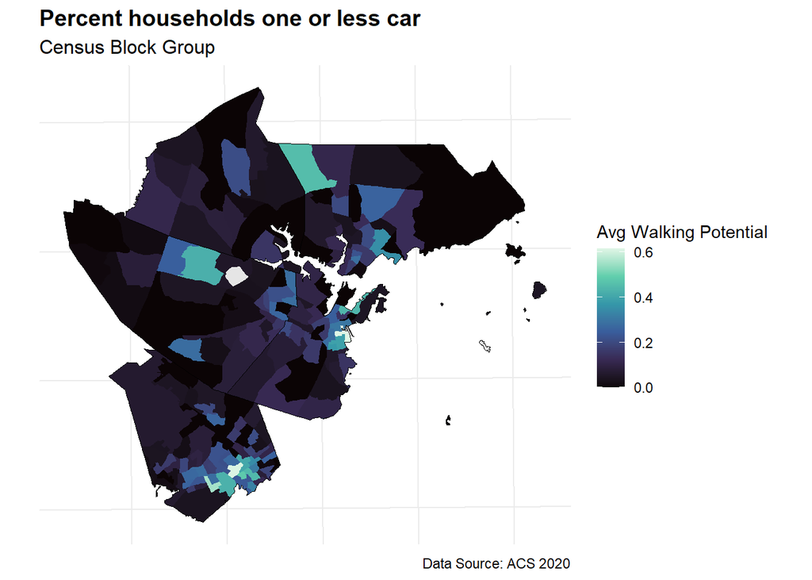

```r
# Create a map of walking one or less variable
ggplot() +
  # Plot block groups with average walking potential
  geom_sf(data = MA_blockgrp_5_walk, aes(fill = prnrlss), color = NA) +
  scale_fill_viridis_c(
    option = "mako",
    name = "Avg Walking Potential",
    na.value = "grey90"
  ) +
  # Overlay town boundaries for context
  geom_sf(data = fivetowns, fill = NA, color = "black", size = 0.5) +
  theme_minimal() +
  labs(
    title = "Percent households one or less car",
    subtitle = "Census Block Group",
    caption = "Data Source: ACS 2020"
  ) +
  theme(
    legend.position = "right",
    plot.title = element_text(size = 14, face = "bold"),
    plot.subtitle = element_text(size = 12),
    axis.text = element_blank(),
    axis.ticks = element_blank()
  ) +
  coord_sf()
```

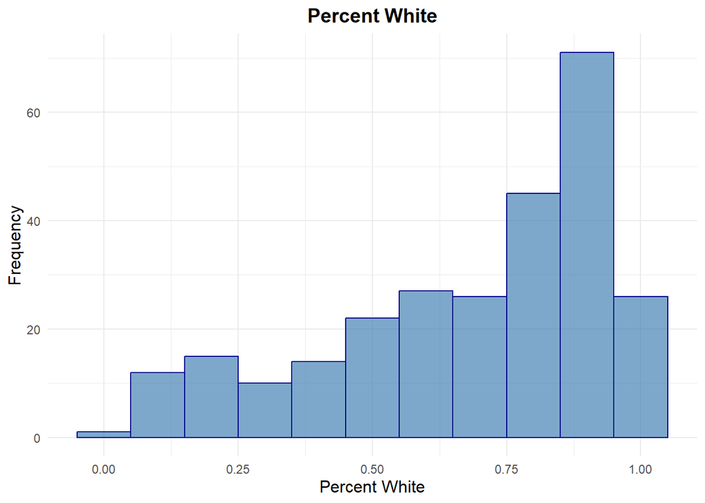

```r
# Create a histogram for percent white
ggplot(MA_blockgrp_5_walk, aes(x = PctWhit)) +
  geom_histogram(binwidth = 0.1, fill = "steelblue", color = "darkblue", alpha = 0.7) +
  labs(
    title = "Percent White",
    x = "Percent White",
    y = "Frequency"
  ) +
  theme_minimal() +
  theme(
    plot.title = element_text(size = 14, face = "bold", hjust = 0.5),
    axis.title.x = element_text(size = 12),
    axis.title.y = element_text(size = 12)
  )
```

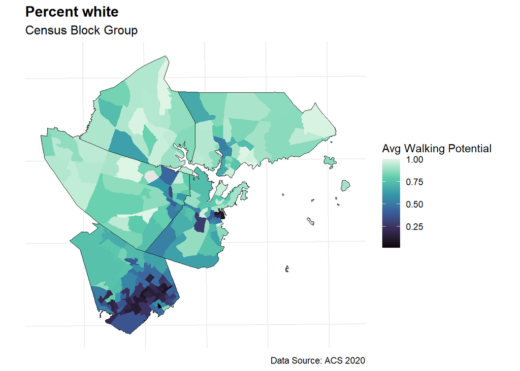

```r
# Create a map of percent white variable
ggplot() +
  geom_sf(data = MA_blockgrp_5_walk, aes(fill = PctWhit), color = NA) +
  scale_fill_viridis_c(
    option = "mako",
    name = "Avg Walking Potential",
    na.value = "grey90"
  ) +
  # Overlay town boundaries for context
  geom_sf(data = fivetowns, fill = NA, color = "black", size = 0.5) +
  theme_minimal() +
  labs(
    title = "Percent white",
    subtitle = "Census Block Group",
    caption = "Data Source: ACS 2020"
  ) +
  theme(
    legend.position = "right",
    plot.title = element_text(size = 14, face = "bold"),
    plot.subtitle = element_text(size = 12),
    axis.text = element_blank(),
    axis.ticks = element_blank()
  ) +
  coord_sf()
```

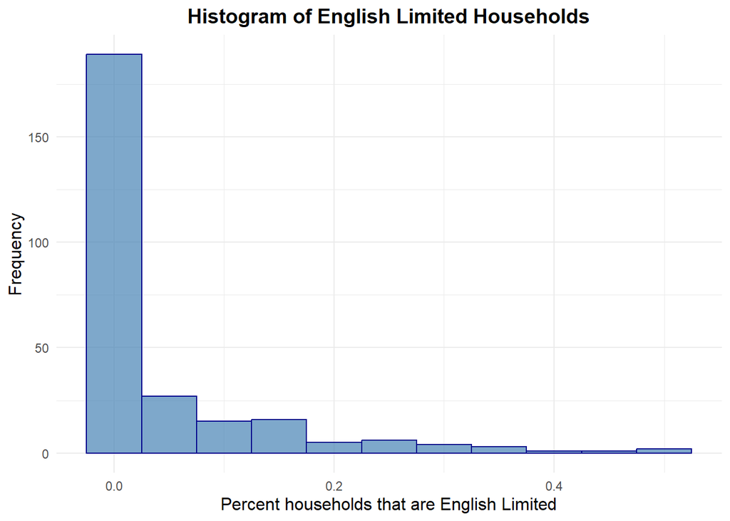

```r
# Create a histogram for english limited
ggplot(MA_blockgrp_5_walk, aes(x = PctLmEn)) +
  geom_histogram(binwidth = 0.05, fill = "steelblue", color = "darkblue", alpha = 0.7) +
  labs(
    title = "Histogram of English Limited Households",
    x = "Percent households that are English Limited",
    y = "Frequency"
  ) +
  theme_minimal() +
  theme(
    plot.title = element_text(size = 14, face = "bold", hjust = 0.5),
    axis.title.x = element_text(size = 12),
    axis.title.y = element_text(size = 12)
  )
```

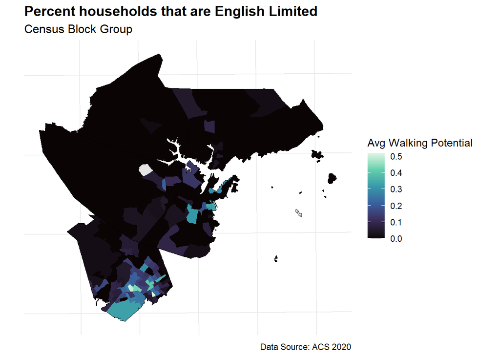

```r
# Create a map of percent english limited variable
ggplot() +
  geom_sf(data = MA_blockgrp_5_walk, aes(fill = PctLmEn), color = NA) +
  scale_fill_viridis_c(
    option = "mako",
    name = "Avg Walking Potential",
    na.value = "grey90"
  ) +
  # Overlay town boundaries for context
  geom_sf(data = fivetowns, fill = NA, color = "black", size = 0.5) +
  theme_minimal() +
  labs(
    title = "Percent households that are English Limited",
    subtitle = "Census Block Group",
    caption = "Data Source: ACS 2020"
  ) +
  theme(
    legend.position = "right",
    plot.title = element_text(size = 14, face = "bold"),
    plot.subtitle = element_text(size = 12),
    axis.text = element_blank(),
    axis.ticks = element_blank()
  ) +
  coord_sf()
```

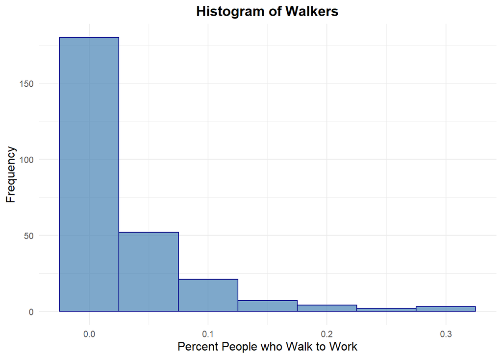

```r
# Create a histogram for percent walkers
ggplot(MA_blockgrp_5_walk, aes(x = prwlkrs)) +
  geom_histogram(binwidth = 0.05, fill = "steelblue", color = "darkblue", alpha = 0.7) +
  labs(
    title = "Histogram of Walkers",
    x = "Percent People who Walk to Work",
    y = "Frequency"
  ) +
  theme_minimal() +
  theme(
    plot.title = element_text(size = 14, face = "bold", hjust = 0.5),
    axis.title.x = element_text(size = 12),
    axis.title.y = element_text(size = 12)
  )
```

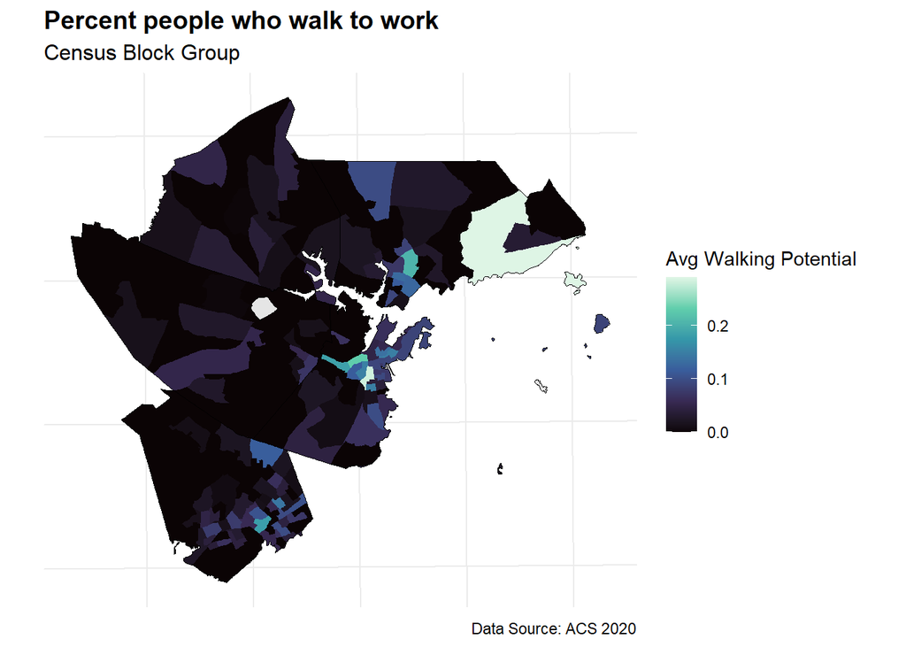

```r
# Create a map of percent walkers variable
ggplot() +
  geom_sf(data = MA_blockgrp_5_walk, aes(fill = prwlkrs), color = NA) +
  scale_fill_viridis_c(
    option = "mako",
    name = "Avg Walking Potential",
    na.value = "grey90"
  ) +
  # Overlay town boundaries for context
  geom_sf(data = fivetowns, fill = NA, color = "black", size = 0.5) +
  theme_minimal() +
  labs(
    title = "Percent people who walk to work",
    subtitle = "Census Block Group",
    caption = "Data Source: ACS 2020"
  ) +
  theme(
    legend.position = "right",
    plot.title = element_text(size = 14, face = "bold"),
    plot.subtitle = element_text(size = 12),
    axis.text = element_blank(),
    axis.ticks = element_blank()
  ) +
  coord_sf()
```

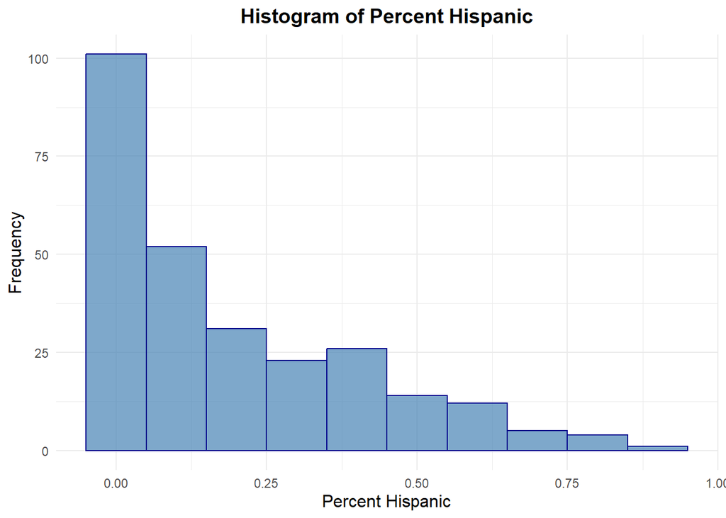

```r
# Create a histogram for percent Hispanic/LatinX
ggplot(MA_blockgrp_5_walk, aes(x = PctHspn)) +
  geom_histogram(binwidth = 0.1, fill = "steelblue", color = "darkblue", alpha = 0.7) +
  labs(
    title = "Histogram of Percent Hispanic",
    x = "Percent Hispanic",
    y = "Frequency"
  ) +
  theme_minimal() +
  theme(
    plot.title = element_text(size = 14, face = "bold", hjust = 0.5),
    axis.title.x = element_text(size = 12),
    axis.title.y = element_text(size = 12)
  )
```

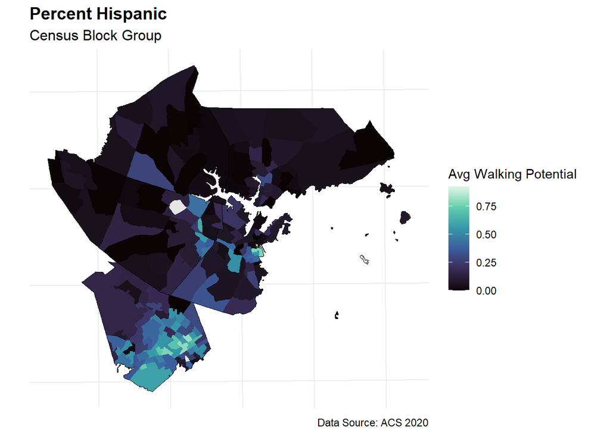

```r
# Create a map of percent hispanic variable
ggplot() +
  geom_sf(data = MA_blockgrp_5_walk, aes(fill = PctHspn), color = NA) +
  scale_fill_viridis_c(
    option = "mako",
    name = "Avg Walking Potential",
    na.value = "grey90"
  ) +
  # Overlay town boundaries for context
  geom_sf(data = fivetowns, fill = NA, color = "black", size = 0.5) +
  theme_minimal() +
  labs(
    title = "Percent Hispanic",
    subtitle = "Census Block Group",
    caption = "Data Source: ACS 2020"
  ) +
  theme(
    legend.position = "right",
    plot.title = element_text(size = 14, face = "bold"),
    plot.subtitle = element_text(size = 12),
    axis.text = element_blank(),
    axis.ticks = element_blank()
  ) +
  coord_sf()
```

```r
################################################################################
###     Random Forest Analysis

names(MA_blockgrp_5_walk)
```

```
##  [1] "STATEFP"   "COUNTYFP"  "TRACTCE"   "BLKGRPC"   "GEOID"     "NAMELSAD"
##  [7] "MTFCC"     "FUNCSTAT"  "ALAND"     "AWATER"    "INTPTLAT"  "INTPTLON"
## [13] "PctWhit"   "PctBlck"   "PctHspn"   "PctLmEn"   "mdHshIE"   "totlppE"
## [19] "pr_bchr"   "prnrlss"   "prwlkrs"   "prpblct"   "prvtrns"   "pr_nmpl"
## [25] "STATEFP2"  "COUNTYFP2" "COUSUBF"   "COUSUBN"   "GEOID20"   "NAMELSAD2"
## [31] "LSAD20"    "CLASSFP"   "MTFCC20"   "CNECTAF"   "NECTAFP"   "NCTADVF"
## [37] "FUNCSTAT2" "ALAND20"   "AWATER2"   "INTPTLAT2" "INTPTLON2" "TOWN20"
## [43] "TOWN_ID"   "FIPS_ST"   "COUNTY2"   "TYPE"      "FOURCOL"   "AREA_AC"
## [49] "SQ_MILE"   "POP1960"   "POP1970"   "POP1980"   "POP1990"   "POP2000"
## [55] "POP2010"   "POP2020"   "POPCH10"   "HOUSING"   "SHAPE_A"   "SHAPE_L"
## [61] "avrg_w_"   "count"     "geometry"
```

```r
MA_blockgrp_5_walk1 <- MA_blockgrp_5_walk %>%
  mutate(
    popdensity = totlppE / ALAND)

# Prepare data for Random Forest
rf_data_geo <- MA_blockgrp_5_walk1 %>%
  filter(!is.na(mdHshIE), !is.na(avrg_w_))


names(rf_data_geo)
```

```
##  [1] "STATEFP"    "COUNTYFP"   "TRACTCE"    "BLKGRPC"    "GEOID"
##  [6] "NAMELSAD"   "MTFCC"      "FUNCSTAT"   "ALAND"      "AWATER"
## [11] "INTPTLAT"   "INTPTLON"   "PctWhit"    "PctBlck"    "PctHspn"
## [16] "PctLmEn"    "mdHshIE"    "totlppE"    "pr_bchr"    "prnrlss"
## [21] "prwlkrs"    "prpblct"    "prvtrns"    "pr_nmpl"    "STATEFP2"
## [26] "COUNTYFP2"  "COUSUBF"    "COUSUBN"    "GEOID20"    "NAMELSAD2"
## [31] "LSAD20"     "CLASSFP"    "MTFCC20"    "CNECTAF"    "NECTAFP"
## [36] "NCTADVF"    "FUNCSTAT2"  "ALAND20"    "AWATER2"    "INTPTLAT2"
## [41] "INTPTLON2"  "TOWN20"     "TOWN_ID"    "FIPS_ST"    "COUNTY2"
## [46] "TYPE"       "FOURCOL"    "AREA_AC"    "SQ_MILE"    "POP1960"
## [51] "POP1970"    "POP1980"    "POP1990"    "POP2000"    "POP2010"
## [56] "POP2020"    "POPCH10"    "HOUSING"    "SHAPE_A"    "SHAPE_L"
## [61] "avrg_w_"    "count"      "geometry"   "popdensity"
```

```r
rf_data_geo_select <- rf_data_geo %>% dplyr::select(avrg_w_, popdensity, PctWhit, PctBlck, PctHspn,PctLmEn,mdHshIE,prnrlss,prwlkrs,prpblct,pr_bchr, prvtrns, pr_nmpl, geometry)

rf_data <- rf_data_geo_select %>% st_drop_geometry()


set.seed(456)
split_index <- createDataPartition(rf_data$avrg_w_, p = 0.8, list = FALSE)
train_data <- rf_data[split_index, ]
test_data <- rf_data[-split_index, ]

# Create the model
rf_model <- randomForest(avrg_w_ ~ ., data = train_data, ntree = 800, importance = TRUE)

# Print the model summary
print(rf_model)
```

```
##
## Call:
##  randomForest(formula = avrg_w_ ~ ., data = train_data, ntree = 800,      importance = TRUE)
##                Type of random forest: regression
##                      Number of trees: 800
## No. of variables tried at each split: 4
##
##           Mean of squared residuals: 82954.2
##                     % Var explained: 57.08
```

```r
# Make predictions on the test set
predictions <- predict(rf_model, test_data)
predictions
```

```
##         3        13        18        28        36        52        56        58
##  223.0461  416.2946  305.5013  387.0020  282.6548  327.3703 1067.5768  496.2895
##        70        71        79        83        87        89        96        99
##  826.0707  135.2515  205.7976  274.1159  844.6479  614.0303  898.0780  831.2440
##       102       105       117       125       128       138       139       141
##  676.3893 1134.5703 1094.7401  490.4951  434.8005  192.8885  239.7391  277.3297
##       146       149       154       158       161       172       181       201
##  213.8139  400.3154  937.9272  272.2617  278.6555  217.3133  126.3765  217.3133
##       203       206       210       212       214       216       218       219
##  450.1433  243.4196  800.2198  875.2405  345.5075  158.2968  181.5059  223.2159
##       220       222       233       234       237       239       241       245
##  236.0999  171.8193  321.3966  315.9125  552.8382  571.7759  179.1759  336.4942
```

```r
#Round to 1 decimal
predictions_rd <- round(predictions, digits = 1)
testdata_rd <- round(test_data$avrg_w_, digits = 1)

# Evaluate accuracy
accuracy <- sum(predictions == test_data) / nrow(test_data)
cat("Accuracy:", accuracy, "\n")
```

```
## Accuracy: 0
```

```r
# Extract feature importance scores
importance_scores <- randomForest::importance(rf_model)

# Print feature importance scores
print(importance_scores)
```

```
##              %IncMSE IncNodePurity
## popdensity 30.120702     8737020.2
## PctWhit    14.762114     2799195.1
## PctBlck    10.519496     1312201.3
## PctHspn    14.115520     2920108.3
## PctLmEn    14.200088     3223325.5
## mdHshIE    11.255009     2414395.3
## prnrlss    15.782379     5195679.0
## prwlkrs    10.774860     2780619.3
## prpblct     9.376848     1886702.9
## pr_bchr     7.996718     1927353.6
## prvtrns     9.891067     2481594.3
## pr_nmpl     3.668416      959421.3
```

```r
sorted_scores <- importance_scores[order(importance_scores[, 1], decreasing = FALSE), , drop = FALSE]

par(mar = c(5, 20, 4, 2),xpd = TRUE)  # Increase left margin (second value) to give space for the labels

# Convert the feature importance scores into a data frame
importance_df <- as.data.frame(importance_scores)
importance_df$Feature <- rownames(importance_scores)
colnames(importance_df) <- c("%IncMSE", "IncNodePurity", "Feature")

names(importance_df)
```

```
## [1] "%IncMSE"       "IncNodePurity" "Feature"
```

```r
# Use the desired importance metric (e.g., "%IncMSE")
importance_df <- importance_df %>%
#  select("Feature", "%IncMSE") %>%
  rename(Importance = "%IncMSE")

# Sort the data by importance
importance_df <- importance_df %>%
  arrange(desc(Importance))

print(importance_df)
```

```
##            Importance IncNodePurity    Feature
## popdensity  30.120702     8737020.2 popdensity
## prnrlss     15.782379     5195679.0    prnrlss
## PctWhit     14.762114     2799195.1    PctWhit
## PctLmEn     14.200088     3223325.5    PctLmEn
## PctHspn     14.115520     2920108.3    PctHspn
## mdHshIE     11.255009     2414395.3    mdHshIE
## prwlkrs     10.774860     2780619.3    prwlkrs
## PctBlck     10.519496     1312201.3    PctBlck
## prvtrns      9.891067     2481594.3    prvtrns
## prpblct      9.376848     1886702.9    prpblct
## pr_bchr      7.996718     1927353.6    pr_bchr
## pr_nmpl      3.668416      959421.3    pr_nmpl
```

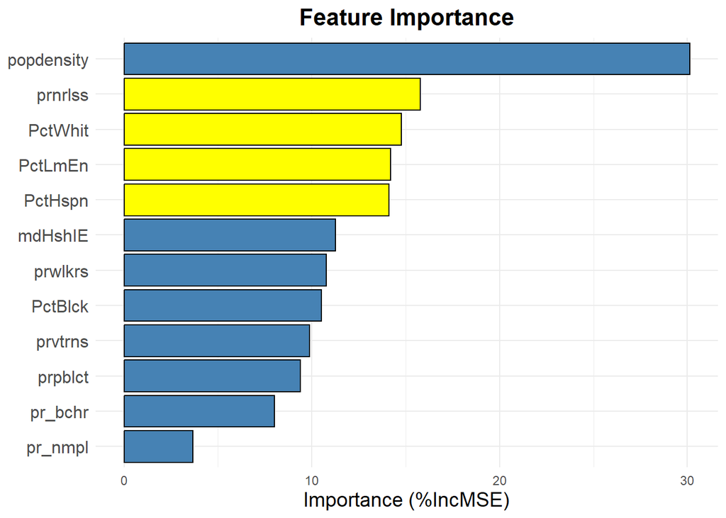

```r
# Highlight specific features in yellow
importance_df$Highlight <- ifelse(importance_df$Feature %in% c("prnrlss", "PctWhit", "PctLmEn", "PctHspn"), "yellow", "steelblue")

# Create the ggplot
importance_plot <- ggplot(importance_df, aes(x = reorder(Feature, Importance), y = Importance, fill = Highlight)) +
  geom_bar(stat = "identity", color = "black") +
  scale_fill_identity() +
  coord_flip() +
  theme_minimal() +
  theme(
    axis.text.y = element_text(size = 12),
    axis.title.x = element_text(size = 14),
    axis.title.y = element_blank(),
    plot.title = element_text(size = 16, face = "bold", hjust = 0.5)
  ) +
  labs(
    title = "Feature Importance",
    x = "Feature",
    y = "Importance (%IncMSE)"
  )

# Print the plot
print(importance_plot)
```

```r
###########################################################################################################             Linear Analysis


# Run the linear model
lm_model <- lm(avrg_w_ ~ prnrlss + PctWhit + PctLmEn + PctHspn + popdensity, data = rf_data)

# Get the summary of the linear model
summary_lm <- summary(lm_model)
print(summary_lm)
```

```
##
## Call:
## lm(formula = avrg_w_ ~ prnrlss + PctWhit + PctLmEn + PctHspn +
##     popdensity, data = rf_data)
##
## Residuals:
##      Min       1Q   Median       3Q      Max
## -1270.80  -166.58   -69.55   124.02  1633.50
##
## Coefficients:
##             Estimate Std. Error t value Pr(>|t|)
## (Intercept)   253.03     185.78   1.362   0.1745
## prnrlss      1028.26     206.63   4.976 1.23e-06 ***
## PctWhit      -105.83     200.52  -0.528   0.5981
## PctLmEn       800.09     358.21   2.234   0.0264 *
## PctHspn        66.65     253.67   0.263   0.7930
## popdensity  33078.66    7689.90   4.302 2.47e-05 ***
## ---
## Signif. codes:  0 '***' 0.001 '**' 0.01 '*' 0.05 '.' 0.1 ' ' 1
##
## Residual standard error: 324.3 on 241 degrees of freedom
## Multiple R-squared:  0.4311, Adjusted R-squared:  0.4193
## F-statistic: 36.52 on 5 and 241 DF,  p-value: < 2.2e-16
```

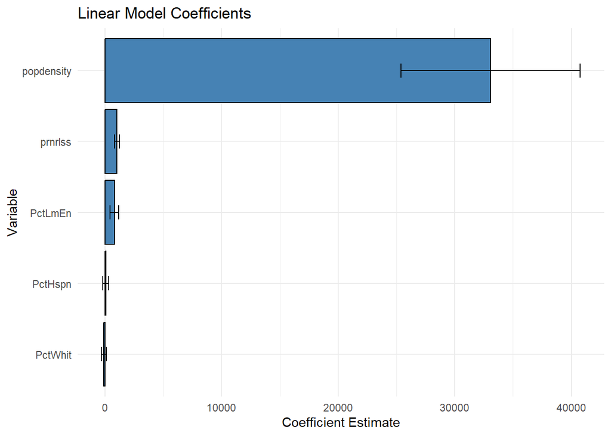

```r
# Visualize linear regression coefficients
coefficients_df <- as.data.frame(summary_lm$coefficients)
coefficients_df$Variable <- rownames(coefficients_df)
colnames(coefficients_df) <- c("Estimate", "Std.Error", "t.value", "Pr(>|t|)", "Variable")
coefficients_df <- coefficients_df[-1, ]  # Exclude the intercept

# Plot the coefficients
coeff_plot <- ggplot(coefficients_df, aes(x = reorder(Variable, Estimate), y = Estimate)) +
  geom_bar(stat = "identity", fill = "steelblue", color = "black") +
  geom_errorbar(aes(ymin = Estimate - Std.Error, ymax = Estimate + Std.Error), width = 0.2) +
  coord_flip() +
  theme_minimal() +
  labs(
    title = "Linear Model Coefficients",
    x = "Variable",
    y = "Coefficient Estimate"
  )

print(coeff_plot)
```

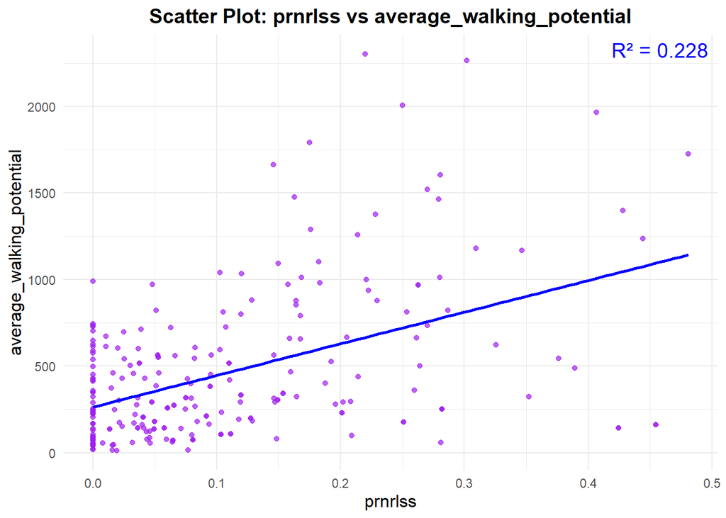

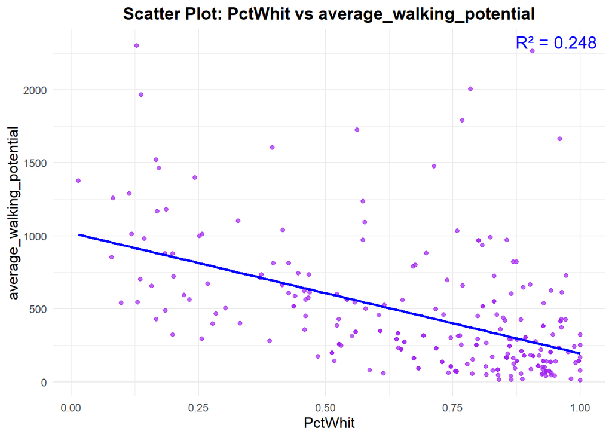

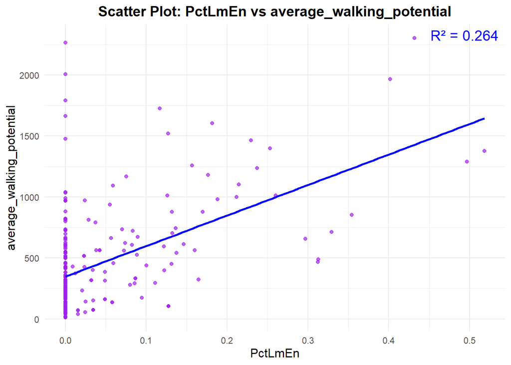

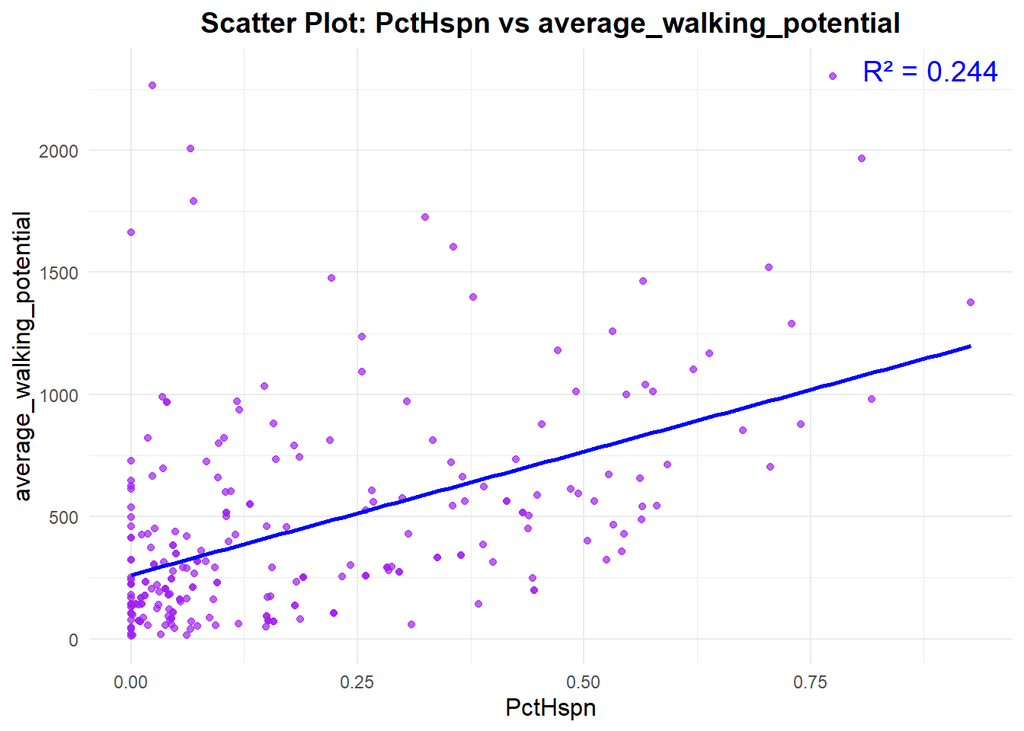

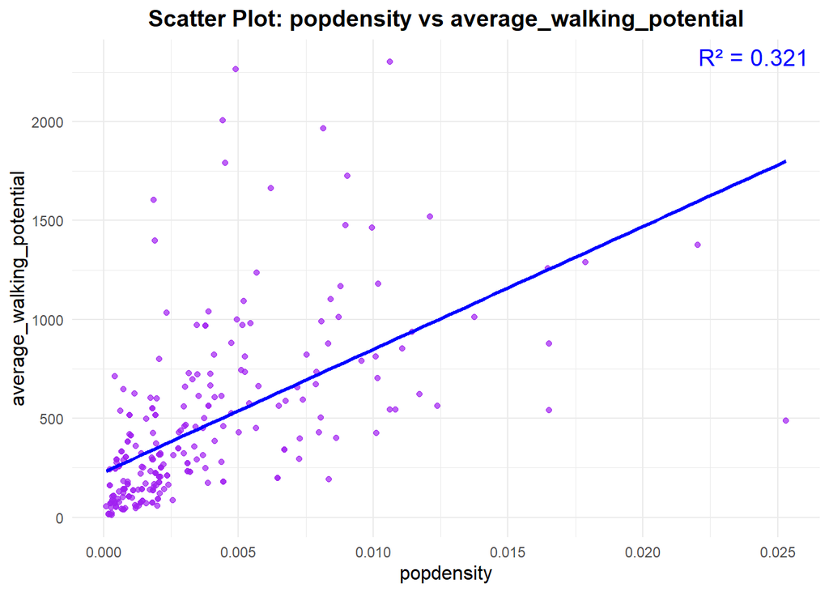

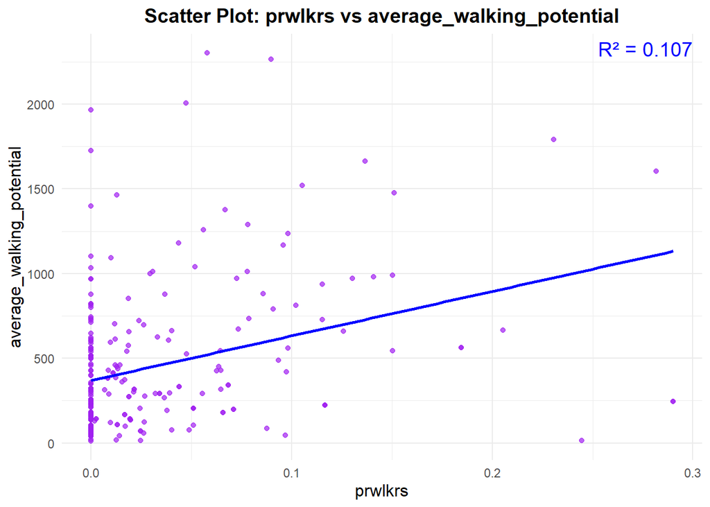

```r
# List of variables to compare with average_walking_potential
scatter_variables <- c("prnrlss", "PctWhit", "PctLmEn", "PctHspn", "popdensity", "prwlkrs")

# Loop through each variable to generate scatter plots with regression lines and R² values
for (var in scatter_variables) {
  # Fit a linear model
  formula <- as.formula(paste("avrg_w_ ~", var))
  lm_model <- lm(formula, data = rf_data)
  r_squared <- summary(lm_model)$r.squared

  # Create the scatter plot with regression line
  p <- ggplot(rf_data_geo, aes_string(x = var, y = "avrg_w_")) +
    geom_point(alpha = 0.7, color = "purple") +
    geom_smooth(method = "lm", se = FALSE, color = "blue") +
    annotate("text", x = Inf, y = Inf, label = paste("R² =", round(r_squared, 3)),
             hjust = 1.1, vjust = 1.5, size = 5, color = "blue") +
    theme_minimal() +
    labs(
      title = paste("Scatter Plot:", var, "vs average_walking_potential"),
      x = var,
      y = "average_walking_potential"
    ) +
    theme(
      plot.title = element_text(hjust = 0.5, size = 14, face = "bold"),
      axis.title = element_text(size = 12)
    )
  print(p)
}
```

Transit Analysis

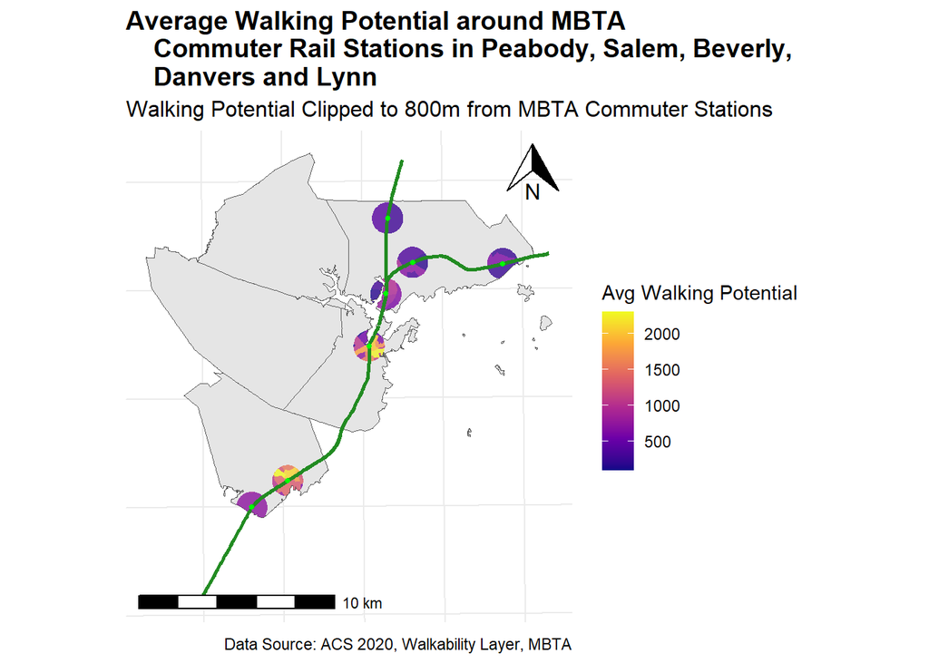

```r
#Towns only
Beverly <- fivetowns %>% filter(NAMELSAD20 %in% c("Beverly city"))
Lynn <- fivetowns %>% filter(NAMELSAD20 %in% c("Lynn city"))
Salem <- fivetowns %>% filter(NAMELSAD20 %in% c("Salem city"))

#Train Buffers (800m)
transitbuffers <- st_buffer(transit_points, dist = 800)

#Clip walkability to Train Buffers
walkabilitytrains <- st_intersection(MA_blockgrp_5_walk, transitbuffers)

#Clip walkability to Towns
walkabilityBeverly <- st_intersection(walkabilitytrains, Beverly) #Beverly
walkabilityLynn <- st_intersection(walkabilitytrains, Lynn) #Lynn
walkabilitySalem <- st_intersection(walkabilitytrains, Salem) #Salem

#Clip Walkability to Food Sites
walkabilityfoodsites <- st_intersection(MA_blockgrp_5_walk, food1_buffers)

#Clip Train Points
transitpointsbeverly <- st_intersection(transit_points, Beverly)
transitpointslynn <- st_intersection(transit_points, Lynn)
transitpointssalem <- st_intersection(transit_points, Salem)

#Clip Train lines
transitlinesbeverly <- st_intersection(transit_lines, Beverly)
transitlineslynn <- st_intersection(transit_lines, Lynn)
transitlinessalem <- st_intersection(transit_lines, Salem)

#Clip Food Sites
foodsitesbeverly <- st_intersection(ALLfoodsites1, Beverly)
foodsiteslynn <- st_intersection(ALLfoodsites1, Lynn)
foodsitessalem <- st_intersection(ALLfoodsites1, Salem)

#Clip Food Site Buffers
foodbuffersbeverly <- st_intersection(food1_buffers, Beverly)
foodbufferslynn <- st_intersection(food1_buffers, Lynn)
foodbufferssalem <- st_intersection(food1_buffers, Salem)

#Food Sites Walkability
ggplot(walkabilitytrains) +
  geom_sf(data = fivetowns) +
  geom_sf(data = , aes(fill = avrg_w_), color = NA, alpha = 0.8) +
  scale_fill_viridis_c(
    option = "plasma",  # Use a brighter palette like "plasma"
    name = "Avg Walking Potential",
    na.value = "grey90",
    direction = 1  # Ensure colors are ascending for brightness
  ) +
  geom_sf(data = transit_lines , fill = NA, color = "forestgreen", linewidth = 1, linetype = "solid") +
  geom_sf(data = transit_points, color = "green", size = 1, shape = 16) +
  theme_minimal() +
  labs(
    title = "Average Walking Potential around MBTA
    Commuter Rail Stations in Peabody, Salem, Beverly,
    Danvers and Lynn",
    subtitle = "Walking Potential Clipped to 800m from MBTA Commuter Stations",
    caption = "Data Source: ACS 2020, Walkability Layer, MBTA"
  ) +
  annotation_scale(location = "bl", width_hint = 0.5) +
  annotation_north_arrow(location = "tr", which_north = "true",
                         height = unit(1, "cm"), width = unit(1, "cm")) +
  theme(
    legend.position = "right",
    plot.title = element_text(size = 14, face = "bold"),
    plot.subtitle = element_text(size = 12),
    axis.text = element_blank(),
    axis.ticks = element_blank()
  ) +
  coord_sf()
```

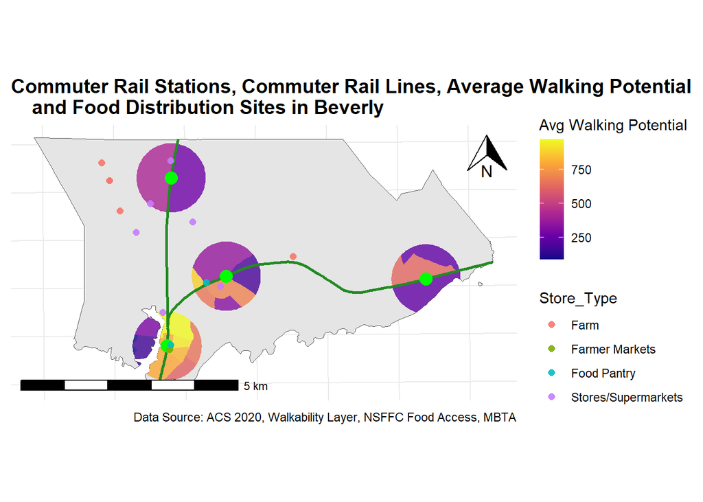

```r
#Beverly Map
ggplot() +
  geom_sf(data = Beverly) +
  geom_sf(data = walkabilityBeverly, aes(fill = avrg_w_), color = NA, alpha = 0.8) +
  scale_fill_viridis_c(
    option = "plasma",  # Use a brighter palette like "plasma"
    name = "Avg Walking Potential",
    na.value = "grey90",
    direction = 1  # Ensure colors are ascending for brightness
  ) +
  geom_sf(data = transitlinesbeverly, fill = NA, color = "forestgreen", linewidth = 1, linetype = "solid") +
  geom_sf(data = transitpointsbeverly, color = "green", size = 4, shape = 16) +
  #geom_sf(data = foodbuffersbeverly, fill = "lightblue", color = NA, alpha = 0.3) +
  geom_sf(data = foodsitesbeverly, aes(color = Store_Type), size = 2, alpha = 0.9) +
  theme_minimal() +
  labs(
    title = "Commuter Rail Stations, Commuter Rail Lines, Average Walking Potential
    and Food Distribution Sites in Beverly",
    caption = "Data Source: ACS 2020, Walkability Layer, NSFFC Food Access, MBTA"
  ) +
  annotation_scale(location = "bl", width_hint = 0.5) +
  annotation_north_arrow(location = "tr", which_north = "true",
                         height = unit(1, "cm"), width = unit(1, "cm")) +
  theme(
    legend.position = "right",
    plot.title = element_text(size = 14, face = "bold"),
    plot.subtitle = element_text(size = 12),
    axis.text = element_blank(),
    axis.ticks = element_blank()
  ) +
  coord_sf()
```

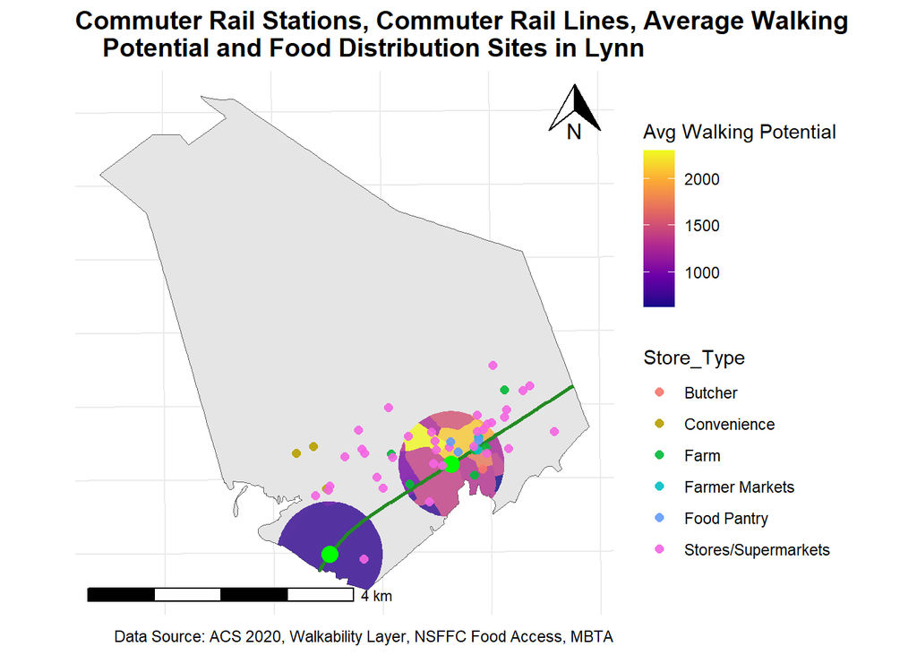

```r
#Lynn Map
ggplot() +
  geom_sf(data = Lynn) +
  geom_sf(data = walkabilityLynn, aes(fill = avrg_w_), color = NA, alpha = 0.8) +
  scale_fill_viridis_c(
    option = "plasma",  # Use a brighter palette like "plasma"
    name = "Avg Walking Potential",
    na.value = "grey90",
    direction = 1  # Ensure colors are ascending for brightness
  ) +
  geom_sf(data = transitlineslynn, fill = NA, color = "forestgreen", linewidth = 1, linetype = "solid") +
  geom_sf(data = transitpointslynn, color = "green", size = 4, shape = 16) +
  #geom_sf(data = foodbufferslynn, fill = "lightblue", color = NA, alpha = 0.3) +
  geom_sf(data = foodsiteslynn, aes(color = Store_Type), size = 2, alpha = 0.9) +
  theme_minimal() +
  labs(
    title = "Commuter Rail Stations, Commuter Rail Lines, Average Walking
    Potential and Food Distribution Sites in Lynn",
    caption = "Data Source: ACS 2020, Walkability Layer, NSFFC Food Access, MBTA"
  ) +
  annotation_scale(location = "bl", width_hint = 0.5) +
  annotation_north_arrow(location = "tr", which_north = "true",
                         height = unit(1, "cm"), width = unit(1, "cm")) +
  theme(
    legend.position = "right",
    plot.title = element_text(size = 14, face = "bold"),
    plot.subtitle = element_text(size = 12),
    axis.text = element_blank(),
    axis.ticks = element_blank()
  ) +
  coord_sf()
```

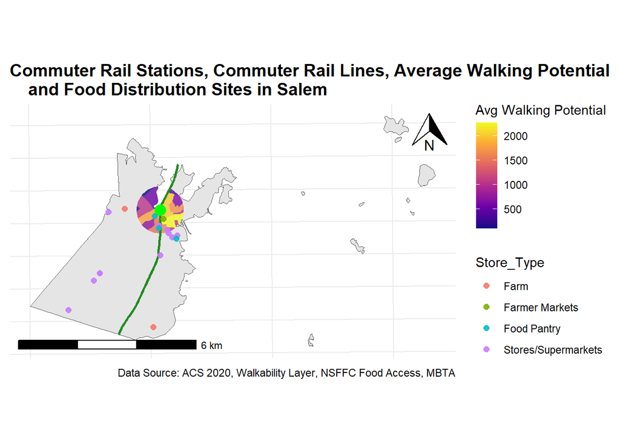

```r
#Salem Map
ggplot() +
  geom_sf(data = Salem) +
  geom_sf(data = walkabilitySalem, aes(fill = avrg_w_), color = NA, alpha = 0.8) +
  scale_fill_viridis_c(
    option = "plasma",  # Use a brighter palette like "plasma"
    name = "Avg Walking Potential",
    na.value = "grey90",
    direction = 1  # Ensure colors are ascending for brightness
  ) +
  geom_sf(data = transitlinessalem, fill = NA, color = "forestgreen", linewidth = 1, linetype = "solid") +
  geom_sf(data = transitpointssalem, color = "green", size = 4, shape = 16) +
  #geom_sf(data = foodbufferssalem, fill = "lightblue", color = NA, alpha = 0.3) +
  geom_sf(data = foodsitessalem, aes(color = Store_Type), size = 2, alpha = 0.9) +
  theme_minimal() +
  labs(
    title = "Commuter Rail Stations, Commuter Rail Lines, Average Walking Potential
    and Food Distribution Sites in Salem",
    caption = "Data Source: ACS 2020, Walkability Layer, NSFFC Food Access, MBTA"
  ) +
  annotation_scale(location = "bl", width_hint = 0.5) +
  annotation_north_arrow(location = "tr", which_north = "true",
                         height = unit(1, "cm"), width = unit(1, "cm")) +
  theme(
    legend.position = "right",
    plot.title = element_text(size = 14, face = "bold"),
    plot.subtitle = element_text(size = 12),
    axis.text = element_blank(),
    axis.ticks = element_blank()
  ) +
  coord_sf()
```

```r
#########################################################################################################                     Findings

#Walkability around each Train Station
# Join transit station and walkability data
walkability_with_station <- st_join(walkabilitytrains, transit_points, join = st_intersects)

# Calculate the average walkability by station
average_walkability_transit <- walkability_with_station %>%
  group_by(STATION.x) %>%
  summarise(
    Avg_Walking_Potential = mean(avrg_w_, na.rm = TRUE)
  )

#Food Sites within Transit Buffers

# Clip food sites to transit buffers
food_sites_transit_buffers <- st_intersection(ALLfoodsites1, transitbuffers)

# Join transit station and food sites
food_sites_with_station <- st_join(food_sites_transit_buffers, transit_points, join = st_intersects)

# Count the number of food sites within each transit station buffer
food_sites_count_by_station <- food_sites_with_station %>%
  group_by(STATION.x) %>%
  summarise(
    Num_Food_Sites = n()
  )

# Merge Above Findings into a table

# Rename the 'STATION' column
colnames(average_walkability_transit)[colnames(average_walkability_transit) == "STATION.x"] <- "STATION"
colnames(food_sites_count_by_station)[colnames(food_sites_count_by_station) == "STATION.x"] <- "STATION"

# Merge the two tables by station name
station_walkability_and_foodsites <- st_join(average_walkability_transit, food_sites_count_by_station, by = "STATION")

names(station_walkability_and_foodsites)
```

```
## [1] "STATION.x"             "Avg_Walking_Potential" "geometry"
## [4] "STATION.y"             "Num_Food_Sites"
```

```r
#Remove geometry
station_walkability_and_foodsites_noy <- station_walkability_and_foodsites %>%
  dplyr::select(-STATION.y)
station_walkability_and_foodsites_no_geom <- st_drop_geometry(station_walkability_and_foodsites_noy)
station_walkability_and_foodsites_no_geom
```

```
## # A tibble: 7 × 3
##   STATION.x     Avg_Walking_Potential Num_Food_Sites
## * <chr>                         <dbl>          <int>
## 1 BEVERLY                        647.              3
## 2 BEVERLY FARMS                  370.             NA
## 3 LYNN                          1388.             22
## 4 MONTSERRAT                     519.              2
## 5 NORTH BEVERLY                  347.              2
## 6 RIVER WORKS                    771.              1
## 7 SALEM                         1105.              5
```